# Classification of quality of weight lifting exercises using wearables’ sensor data

Andreas Raencker

15 April 2017

## Synopsis

Using publicly available [data](http://groupware.les.inf.puc-rio.br/har) we applied machine learning techniques to create a model that classifies the quality of execution of weight lifting exercises based on wearables’ sensor data. The model was applied on 20 test cases then. We fitted 3 different models applying the following machine learning methods from R’s caret package: rpart, random forest and gbm. The random forest provided the best result with 99.1% accuracy (estimated on an independent validation set). It was able to correctly predict the outcome for the 20 test cases. However, it required the highest amount of computing power.

## Data Processing

We load the training and test data from the downloaded csv file.

It appears that the training dataset is not tidy with respect to the outcome to be predicted. Each row represents sensor data at a specific point in time while exercises take some time. Thus there are several sensor observations per exercise.

However, the test data contains 20 point in time observations only. Thus the prediction algorithm is to be designed on such data. Consequently we cannot use the aggregated features from the training data for prediction. We furthermore deem columns “X”, “user_name”, the 3 “timestamp” columns and the 2 “window” columns as inappropriate for predicting “classe”.

To perform cross validation we create subsets for training (60%), testing (20%) and validation (20%).

```r
rd <- read.csv("pml-training.csv")
td <- read.csv("pml-testing.csv")

ad <- subset(rd,
             select = c(grep("^(roll|pitch|yaw|total|gyros|accel|magnet)",
                             colnames(rd), value = TRUE), "classe"))

suppressPackageStartupMessages(library(caret))
set.seed(20170415)
inValidation <- createDataPartition(ad$classe, p = 0.2)[[1]]
validation <- ad[inValidation,]
modelling <- ad[-inValidation,]
inTraining <- createDataPartition(modelling$classe, p = 0.75)[[1]]
training <- modelling[inTraining,]
testing <- modelling[-inTraining,]
```

## Exploratory Analysis

A summary of the training set particularly reveals skewness in the distribution of some of the gyros and magnet variables. As an example we show a density plot of the variable “gyros_forearm_y”.

```r
summary(training)
```

```
##    roll_belt        pitch_belt          yaw_belt       total_accel_belt
##  Min.   :-28.90   Min.   :-53.9000   Min.   :-180.00   Min.   : 0.00
##  1st Qu.:  1.09   1st Qu.:  1.9100   1st Qu.: -88.30   1st Qu.: 3.00
##  Median :113.00   Median :  5.3100   Median : -14.30   Median :17.00
##  Mean   : 64.01   Mean   :  0.5135   Mean   : -12.33   Mean   :11.27
##  3rd Qu.:123.00   3rd Qu.: 14.9250   3rd Qu.:   6.78   3rd Qu.:18.00
##  Max.   :162.00   Max.   : 60.3000   Max.   : 179.00   Max.   :28.00
##   gyros_belt_x        gyros_belt_y       gyros_belt_z
##  Min.   :-1.000000   Min.   :-0.64000   Min.   :-1.4600
##  1st Qu.:-0.050000   1st Qu.: 0.00000   1st Qu.:-0.2000
##  Median : 0.030000   Median : 0.02000   Median :-0.1000
##  Mean   :-0.007449   Mean   : 0.03935   Mean   :-0.1291
##  3rd Qu.: 0.110000   3rd Qu.: 0.11000   3rd Qu.:-0.0200
##  Max.   : 1.980000   Max.   : 0.63000   Max.   : 1.6100
##   accel_belt_x       accel_belt_y     accel_belt_z    magnet_belt_x
##  Min.   :-120.000   Min.   :-65.00   Min.   :-268.0   Min.   :-52.00
##  1st Qu.: -21.000   1st Qu.:  3.00   1st Qu.:-162.0   1st Qu.:  9.00
##  Median : -15.000   Median : 31.00   Median :-151.0   Median : 34.00
##  Mean   :  -5.897   Mean   : 30.05   Mean   : -71.9   Mean   : 54.68
##  3rd Qu.:  -5.000   3rd Qu.: 61.00   3rd Qu.:  28.0   3rd Qu.: 58.00
##  Max.   :  81.000   Max.   :164.00   Max.   : 104.0   Max.   :476.00
##  magnet_belt_y   magnet_belt_z       roll_arm         pitch_arm
##  Min.   :359.0   Min.   :-623.0   Min.   :-180.00   Min.   :-87.900
##  1st Qu.:582.0   1st Qu.:-375.0   1st Qu.: -32.02   1st Qu.:-25.800
##  Median :601.0   Median :-320.0   Median :   0.00   Median :  0.000
##  Mean   :593.8   Mean   :-345.6   Mean   :  17.72   Mean   : -4.502
##  3rd Qu.:610.0   3rd Qu.:-306.0   3rd Qu.:  77.33   3rd Qu.: 11.100
##  Max.   :673.0   Max.   : 293.0   Max.   : 179.00   Max.   : 86.800
##     yaw_arm         total_accel_arm  gyros_arm_x        gyros_arm_y
##  Min.   :-180.000   Min.   : 1.00   Min.   :-6.37000   Min.   :-3.3700
##  1st Qu.: -43.300   1st Qu.:17.00   1st Qu.:-1.36000   1st Qu.:-0.7900
##  Median :   0.000   Median :27.00   Median : 0.05000   Median :-0.2200
##  Mean   :  -1.065   Mean   :25.62   Mean   : 0.02442   Mean   :-0.2485
##  3rd Qu.:  45.525   3rd Qu.:33.00   3rd Qu.: 1.53000   3rd Qu.: 0.1600
##  Max.   : 180.000   Max.   :65.00   Max.   : 4.87000   Max.   : 2.8400
##   gyros_arm_z       accel_arm_x       accel_arm_y       accel_arm_z
##  Min.   :-2.3300   Min.   :-371.00   Min.   :-318.00   Min.   :-613.00
##  1st Qu.:-0.0700   1st Qu.:-244.00   1st Qu.: -53.00   1st Qu.:-145.00
##  Median : 0.2300   Median : -45.00   Median :  14.00   Median : -47.00
##  Mean   : 0.2684   Mean   : -60.97   Mean   :  33.02   Mean   : -72.08
```

[output cut: 50 more lines]

```
##  Max.   :311.000   Max.   :231.0000   Max.   : 389.00   Max.   : 923.0
##  accel_forearm_z   magnet_forearm_x  magnet_forearm_y    magnet_forearm_z
##  Min.   :-446.00   Min.   :-1280.0   Min.   :-885.0000   Min.   :-966.0
##  1st Qu.:-182.25   1st Qu.: -612.0   1st Qu.:  -0.0308   1st Qu.: 185.0
##  Median : -43.00   Median : -373.5   Median : 589.0000   Median : 512.0
##  Mean   : -56.52   Mean   : -309.2   Mean   : 377.5496   Mean   : 394.4
##  3rd Qu.:  26.00   3rd Qu.:  -70.0   3rd Qu.: 736.0000   3rd Qu.: 653.0
##  Max.   : 291.00   Max.   :  672.0   Max.   :1480.0000   Max.   :1090.0
##  classe
##  A:3348
##  B:2278
##  C:2053
##  D:1929
##  E:2164
##
```

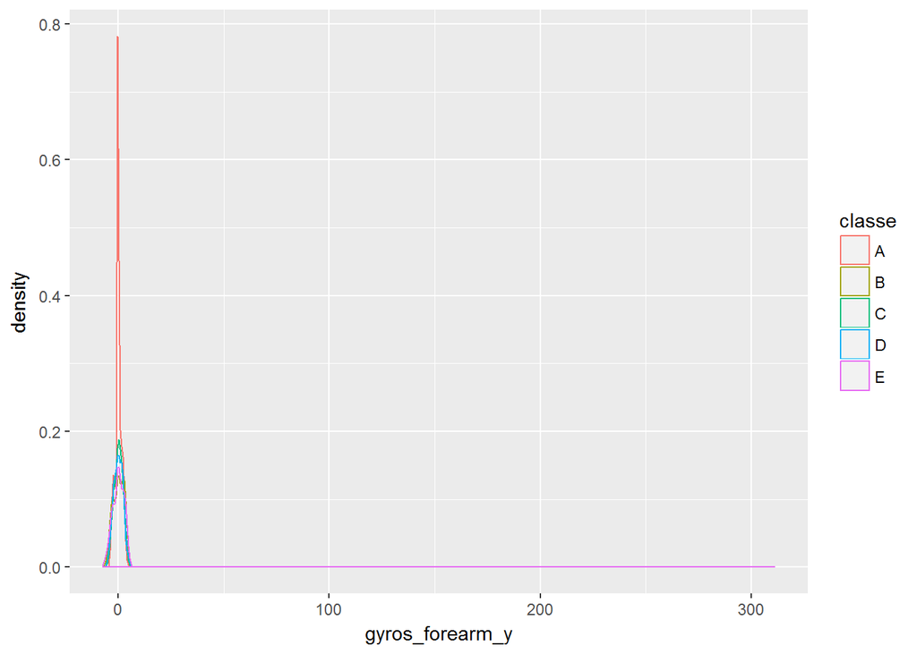

```r
qplot(gyros_forearm_y, data = training, color = classe, geom = "density")
```

## Model Building

We train 3 different models: a tree, a random forest and a gbm. We select the model that performs best on the test set. Choice of the techniques is justified by the fact that we aim at predicting a factor. Furthermore, these methods are robust regarding skewed distributions.

```r
system.time(fit_tree <- train(classe ~ ., data = training, method = "rpart"))
```

```
##    user  system elapsed
##   16.62    0.64   17.60
```

```r
system.time(fit_rf <- train(classe ~ ., data = training, method = "rf", verbose = FALSE))
```

```
##    user  system elapsed
## 3609.53   16.22 3631.50
```

```r
system.time(fit_gbm <- train(classe ~ ., data = training, method = "gbm", verbose = FALSE))
```

```
##    user  system elapsed
## 1538.58    2.72 1552.85
```

```r
confusionMatrix(predict(fit_tree, newdata = testing), testing$classe)$overall
```

```
##       Accuracy          Kappa  AccuracyLower  AccuracyUpper   AccuracyNull
##   4.978333e-01   3.443060e-01   4.820663e-01   5.136035e-01   2.844762e-01
## AccuracyPValue  McnemarPValue
##  4.103366e-174            NaN
```

```r
confusionMatrix(predict(fit_rf, newdata = testing), testing$classe)$overall
```

```
##       Accuracy          Kappa  AccuracyLower  AccuracyUpper   AccuracyNull
##      0.9915881      0.9893567      0.9882066      0.9942027      0.2844762
## AccuracyPValue  McnemarPValue
##      0.0000000            NaN
```

```r
confusionMatrix(predict(fit_gbm, newdata = testing), testing$classe)$overall
```

```
##       Accuracy          Kappa  AccuracyLower  AccuracyUpper   AccuracyNull
##   0.9594697935   0.9487222509   0.9528199290   0.9654235827   0.2844761662
## AccuracyPValue  McnemarPValue
##   0.0000000000   0.0000411487
```

The accuracy of the tree model is not acceptable. The random forest model has the highest accuracy on the testing set. It’s accuracy on the test set is also significantly higher than the gbm model’s accuracy. Thus we choose the random forest model as our final model.

## Estimating model accuracy

Accuracy is estimated on the validation set.

```r
confusionMatrix(predict(fit_rf, newdata = validation), validation$classe)$overall
```

```
##       Accuracy          Kappa  AccuracyLower  AccuracyUpper   AccuracyNull
##      0.9910873      0.9887230      0.9876263      0.9937844      0.2841864
## AccuracyPValue  McnemarPValue
##      0.0000000            NaN
```

The final model’s accuracy is estimated has 99.11% with a 95% confidence interval of [98.76%, 99.38%]. Consequently we expect an out of sample misclassificaton rate of about 1%.

## Application to test data

```r
predict(fit_rf, newdata = td)
```

```
##  [1] B A B A A E D B A A B C B A E E A B B B
## Levels: A B C D E
```

## Appendix

### References

Velloso, E.; Bulling, A.; Gellersen, H.; Ugulino, W.; Fuks, H. Qualitative Activity Recognition of Weight Lifting Exercises. Proceedings of 4th International Conference in Cooperation with SIGCHI (Augmented Human ’13) . Stuttgart, Germany: ACM SIGCHI, 2013.